# Homework 10

Jess Wikle

4/1/2020

# For loops and randomization tests

1. Using a `for`loop, write a function to calculate the number of zeroes in a numeric vector. Before entering the loop, set up a counter variable `counter <- 0`. Inside the loop, add 1 to `counter` each time you have a zero in the matrix. Finally, use `return(counter)` for the output.

```r
# create a numeric vector containing some 0's
my_vec <- rpois(100, lambda = 2)

# -------------------------------
# FUNCTION count_zeros
# description: counts number of zeros in numeric vector
# inputs: numeric vector
# outputs: number of zeros in vector
###################################
count_zeros <- function(vec = rnorm(n = 10, mean = 0, sd = 1)){

# counter variable 0
counter <- 0

  for(i in seq_along(vec)){
  if(vec[i] == 0){
    counter <- counter + 1
  }

}

  return(counter)
} # end of count_zeros
#--------------------------------

# test 1
count_zeros()
```

```
## [1] 0
```

```r
# test 2
count_zeros(vec = my_vec)
```

```
## [1] 10
```

2. Use subsetting instead of a loop to rewrite the function as a single line of code

```r
length(my_vec[my_vec == 0])
```

```
## [1] 10
```

3. Write a function that takes as input two integers representing the number of rows and columns in a matrix. The output is a matrix of these dimensions in which each element is the product of the row number x the column number.

```r
# -------------------------------
# FUNCTION matrix_fun
# description: creates a matrix of certain dimensions where each element is the product of row * column number
# inputs: two integers (row and column)
# outputs: matrix
###################################
matrix_fun <- function(x  = 2, y = 3){

mat1 <- matrix(nrow = x, ncol = y)

for(i in 1:nrow(mat1)){
  for(j in 1:ncol(mat1)){
    mat1[i,j] <- i * j
  }
}

return(mat1)

} # end of matrix_fun
#--------------------------------

# test function
matrix_fun()
```

```
##      [,1] [,2] [,3]
## [1,]    1    2    3
## [2,]    2    4    6
```

```r
# test with different values
matrix_fun(x = 3, y = 5)
```

```
##      [,1] [,2] [,3] [,4] [,5]
## [1,]    1    2    3    4    5
## [2,]    2    4    6    8   10
## [3,]    3    6    9   12   15
```

4. Use the code from the upcoming April 2nd lecture (Randomization Tests) to design and conduct a randomization test for some of your own data. You will need to modify the functions that read in the data, calculate the metric, and randomize the data. Once those are set up, the program should run correctly calling your new functions. Also, to make your analysis fully repeatable, make sure you set the random number seed at the beginning (use either `set.seed()` in base R, or `char2seed` in the TeachingDemos package.

```r
# Load packages
library(TeachingDemos)
library(ggplot2)

# set seed for repeatiblity
char2seed("Disturbance Severity")

# -------------------------------
# FUNCTION read_data
# description: read in (or generate) data for analysis
# inputs: file name (or nothing, as in this demo)
# outputs: 3 column data frame of observed data (ID, x, y)
###################################
read_data <- function(z = NULL){
  if(is.null(z)){
    x_obs <- 1:20
    y_obs <- x_obs + 10 * rnorm(20)
    df <- data.frame(ID = seq_along(x_obs),
                     x_obs,
                     y_obs)
  }
df <- read.table(file = z,
                 header = TRUE,
                 sep = ",",
                 stringsAsFactors = FALSE)
return(df)

} # end of read_data
#--------------------------------
#read_data()

# -------------------------------
# FUNCTION get_metric
# description: calculate metric for randomization test
# inputs: 3 column data frame for regression
# outputs: regression slope
###################################
get_metric <- function(z = NULL){
  if(is.null(z)){
    x_obs <- 1:20
    y_obs <- x_obs + 10 * rnorm(20)
    z <- data.frame(ID = seq_along(x_obs),
                    x_obs,
                    y_obs)
  }
  . <- lm(z[,3] ~ z[,2])
  . <- summary(.)
  . <- .$coefficients[2,1]
  slope <- .
return(slope)

} # end of get_metric
#--------------------------------
#get_metric()

# -------------------------------
# FUNCTION shuffle_data
# description: randomize data for regression analysis
# inputs: 3 column data frame (ID, x, y)
# outputs: 3 column data frame (ID, x, y)
###################################
shuffle_data <- function(z = NULL){
  if(is.null(z)){
    x_obs <- 1:20
    y_obs <- x_obs + 10 * rnorm(20)
    z <- data.frame(ID = seq_along(x_obs),
                    x_obs,
                    y_obs)
  }
z[,3] <- sample(z[,3])
return(z)

} # end of shuffle_data
#--------------------------------
# shuffle_data()
# -------------------------------
# FUNCTION get_pval
# description: calculates p value from simulation
# inputs: list of observed metric and vector of simulated metrics
# outputs: lower and upper tail probability value
###################################
get_pval <- function(z = NULL){
  if(is.null(z)){
    z <- list(rnorm(1), rnorm(1000))
  }
    p_lower <- mean(z[[2]] <= z[[1]])
    p_upper <- mean(z[[2]] >= z[[1]])


return(c(pL = p_lower, pU = p_upper))

} # end of get_pval
#--------------------------------
# get_pval()
# -------------------------------
# FUNCTION plot_ran_test
# description: create a ggplot of histogram of simulated values
# inputs: list of observed metric and vector simulated metrics
# outputs: saved ggplot graph
###################################
plot_ran_test <- function(z = NULL){
  if(is.null(z)){
    z <- list(rnorm(1), rnorm(1000))
  }
df <- data.frame(ID = seq_along(z[[2]]),
                 sim_x = z[[2]])
p1 <- ggplot(data = df, aes(x = sim_x))
p1 + geom_histogram(aes(fill = I("coral"),
                        colour = I("black"))) +
  geom_vline(aes(xintercept = z[[1]], colour = "dodgerblue"))

} # end of plot_ran_test
#--------------------------------
# plot_ran_test()

# Put it all together ------------------------------

# data for simulation: predictor variable is disturbance severity index (DSI), which is the change in aboveground biomass from pretreatment to post-treatment.
# response variable is total number of seedlings in each plot 2 years after treatment
simdata <- "simdata2.csv"

n_sim <- 1000 # number of simulated datasets
x_sim <- rep(NA, n_sim) # vector of NA values length of simulation

# read in data for simulation
df <- read_data(simdata)

# get slope of observed data
x_obs <- get_metric(df)

# use for loop to generate slop values for simulation
for(i in seq_len(n_sim)){
  x_sim[i] <- get_metric(shuffle_data(df))
}

# create slopes object for tests
slopes <- list(x_obs, x_sim)

# get upper and lower tail p-values
get_pval(slopes)
```

```
##    pL    pU
## 0.414 0.586
```

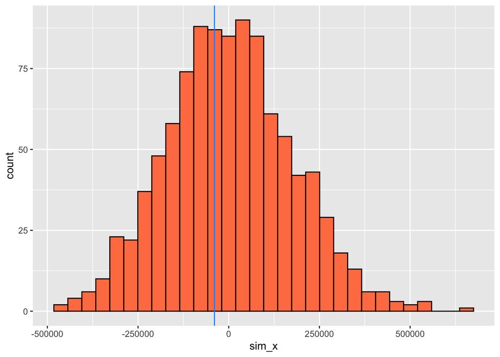

```r
# plot observed vs. simulated tests
plot_ran_test(slopes)
```

5. For comparison, calculate in R the standard statistical analysis you would use with these data. How does the p-value compare for the standard test versus the p value you estimated from your randomization test? If the p values seem very different, run the program again with a different starting seed (and/or increase the number of replications in your randomization test). If there are persistent differences in the p value of the standard test versus your randomization, what do you think is responsible for this difference?

```r
# From multiple run throughs of above: both pL and pU tend to range from 0.4 - 0.6

# regression model of simdata
m1 <- lm(seed_num ~ DSI, data = df)
summary(m1)
```

```
##
## Call:
## lm(formula = seed_num ~ DSI, data = df)
##
## Residuals:
##     Min      1Q  Median      3Q     Max
## -683411 -471777 -180209  349584 3050729
##
## Coefficients:
##             Estimate Std. Error t value Pr(>|t|)
## (Intercept)   675122      61824  10.920   <2e-16 ***
## DSI           -39441     172191  -0.229    0.819
## ---
## Signif. codes:  0 '***' 0.001 '**' 0.01 '*' 0.05 '.' 0.1 ' ' 1
##
## Residual standard error: 635600 on 194 degrees of freedom
##   (1 observation deleted due to missingness)
## Multiple R-squared:  0.0002704,  Adjusted R-squared:  -0.004883
## F-statistic: 0.05246 on 1 and 194 DF,  p-value: 0.8191
```

```r
# the p-values are different, but in both cases, DSI is not a significant predictor of number of seedlings
```